# R Notebook

# Question 1

Using the same crime data set as in Homework 3 Question 4, apply Principal Component Analysis and then create a regression model using the first 4 principal components. Specify your new model in terms of the original variables (not the principal components), and compare its quality to that of your solution to Homework 3 Question 4. You can use the R function prcomp for PCA. (Note that to first scale the data, you can include scale. = TRUE to scale as part of the PCA function.)

```r
library(knitr)
library(ggplot2)
library(plotly)
library(RColorBrewer)
library(DAAG)
```

```r
df<-read.table('uscrime.txt',header=TRUE)
```

### Running PCA

Running PCA is simple as a single line. We need to make sure we scale the data to make sure that when PCA determines the most variance in a certain direction, all the data is scaled to the same dimension or else data with large values will probably show the largest variance.

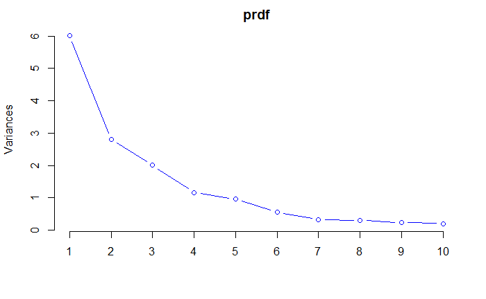

```r
prdf <- prcomp(df[,1:15],scale=TRUE)
screeplot(prdf, type="lines",col="blue")
```

### PCA variance

To see how much of the variance PCA captures per individual

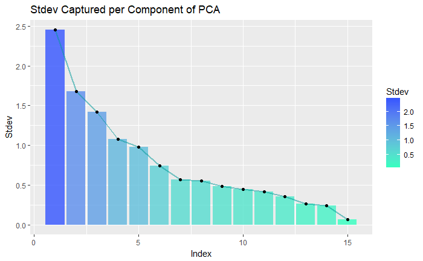

```r
pcaStdv <- data.frame(prdf$sdev)
pcaStdv$idx <- as.numeric(row.names(pcaStdv))
colnames(pcaStdv) <- c("Stdev","Index")
ggplot(pcaStdv,aes(x=Index,y=Stdev,fill=Stdev))+geom_bar(stat="identity",alpha=0.8)+geom_line(color='#009999',size=1,alpha=0.5)+geom_point()+scale_fill_gradient(low="#33FFBF",high="#3354FF")+labs(title="Stdev Captured per Component of PCA")
```

From the above data, we do see an elbow joint at 4 PCA components but also another one at 7 PCA components. The homework asked us to use 4 but I am curious to see if using 7 will provide any additional improvements.

### Running lm on PCA

I decided to run lm on PCA with 4 components, 7 components, and all 15 components. I compared this to our previous lm model which we ran for all of the variables none PCAed and the variables we selected to be the best. Below is the result.

```r
pcaFour <- data.frame(cbind(prdf$x[,1:4],df$Crime))
pcaSeven <- data.frame(cbind(prdf$x[,1:7],df$Crime))
pcaFifteen <- data.frame(cbind(prdf$x[,1:15],df$Crime))
modelFour <- lm(V5~.,data=pcaFour)
modelSeven <- lm(V8~.,data=pcaSeven)
modelFifteen <- lm(V16~.,data=pcaFifteen)
modelSelect <- lm(Crime~Ineq+Ed+Prob+M+U2+Po1+Crime,data=df)
```

```r
modelAll <- lm(Crime~.,data=df)
cvFour <- cv.lm(pcaFour,modelFour,m=5,plotit=FALSE)
cvSeven <- cv.lm(pcaSeven,modelSeven,m=5,plotit=FALSE)
cvFifteen <- cv.lm(pcaFifteen,modelFifteen,m=5,plotit=FALSE)
cvSelect <- cv.lm(df,modelSelect,m=5,plotit=FALSE)
```

```r
cvAll <- cv.lm(df,modelAll,m=5,plotit=FALSE)
```

### R^2 of cross validation

Below I did a comparison of all the different model’s R^2 value to see which one works the best.

```r
SStot <- sum((df$Crime - mean(df$Crime))^2)
SSres_Four <- attr(cvFour,"ms")*nrow(df)
SSres_Seven <- attr(cvSeven,"ms")*nrow(df)
SSres_Fifteen <- attr(cvFifteen,"ms")*nrow(df)
SSres_Select <- attr(cvSelect,"ms")*nrow(df)
SSres_All <- attr(cvAll,"ms")*nrow(df)
R2_Four <- 1-SSres_Four/SStot
R2_Seven <- 1-SSres_Seven/SStot
R2_Fifteen <- 1-SSres_Fifteen/SStot
R2_Select <- 1-SSres_Select/SStot
R2_All <- 1-SSres_All/SStot
print(paste0("R^2 value of model Four is: ",R2_Four))
```

```
[1] "R^2 value of model Four is: 0.105671184448938"
```

```r
print(paste0("R^2 value of model Seven is: ",R2_Seven))
```

```
[1] "R^2 value of model Seven is: 0.456232483740589"
```

```r
print(paste0("R^2 value of model Fifteen is: ",R2_Fifteen))
```

```
[1] "R^2 value of model Fifteen is: 0.413363818818907"
```

```r
print(paste0("R^2 value of model Select is: ",R2_Select))
```

```
[1] "R^2 value of model Select is: 0.638459146624993"
```

```r
print(paste0("R^2 value of model All is: ",R2_All))
```

```
[1] "R^2 value of model All is: 0.413363818818906"
```

Using the selected values from our last homework assignment still gave the best scores, however, if we had to run PCA, picking 7 components rather than 4 gave a significantly better performance.

### Plotting Fitted Value Against Actual Value

Now we can plot the fitted value against the actual value to see how well they lined up. I’ve also included a scaled residual plot to do some additional visual comparisons

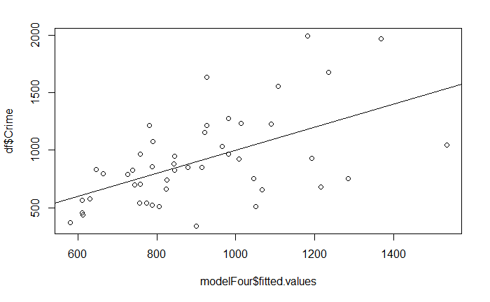

```r
plot(modelFour$fitted.values, df$Crime)
abline(0,1)
```

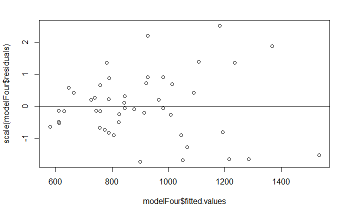

```r
plot(modelFour$fitted.values, scale(modelFour$residuals))
abline(0,0)
```

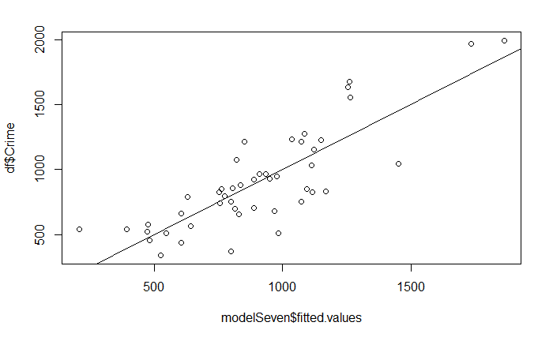

```r
plot(modelSeven$fitted.values, df$Crime)
abline(0,1)
```

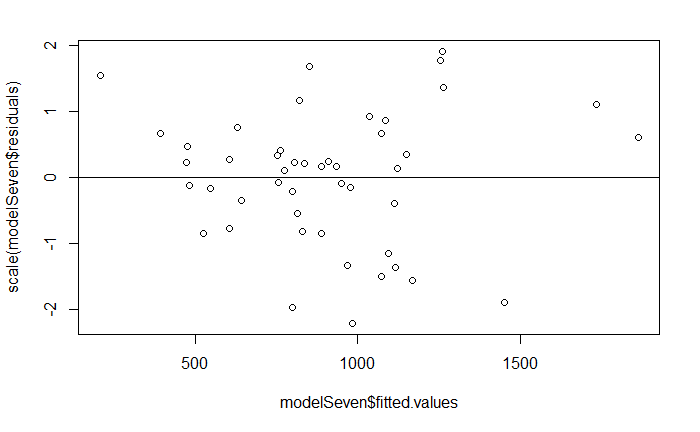

```r
plot(modelSeven$fitted.values, scale(modelSeven$residuals))
abline(0,0)
```

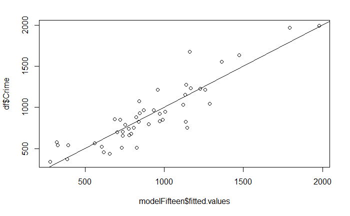

```r
plot(modelFifteen$fitted.values, df$Crime)
abline(0,1)
```

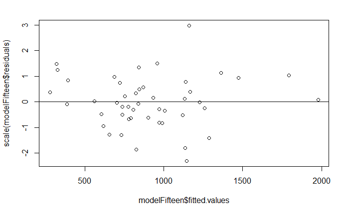

```r
plot(modelFifteen$fitted.values, scale(modelFifteen$residuals))
abline(0,0)
```

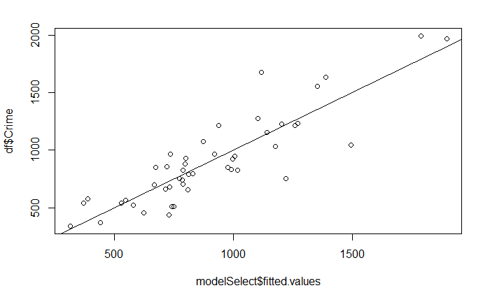

```r
plot(modelSelect$fitted.values, df$Crime)
abline(0,1)
```

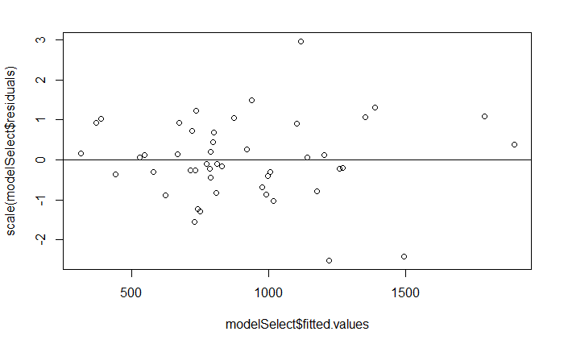

```r
plot(modelSelect$fitted.values, scale(modelSelect$residuals))
abline(0,0)
```

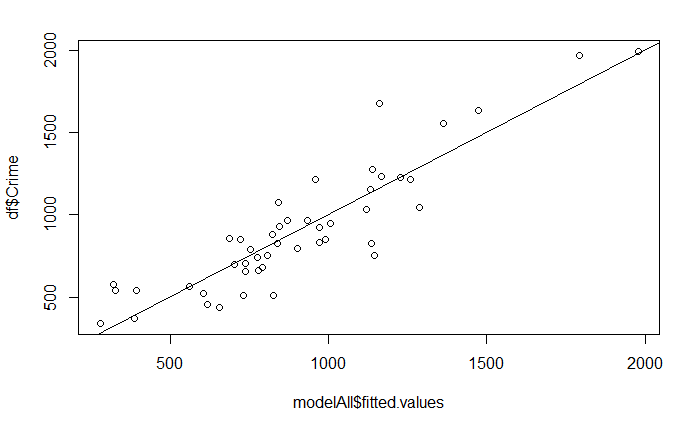

```r
plot(modelAll$fitted.values, df$Crime)
abline(0,1)
```

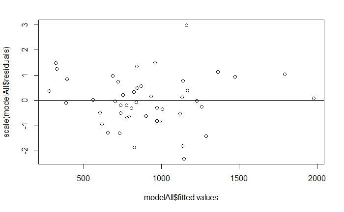

```r
plot(modelAll$fitted.values, scale(modelAll$residuals))
abline(0,0)
```

### PCA coefficient to data coefficient

To get the original coefficients, you would need to multiply the coefficients of the PCA model by the eigenvectors generated from PCA, this was made easy using the $rotation dataframe of pca.

```r
beta0 <- modelFour$coefficients[1]
betas <- modelFour$coefficients[2:5]
alphas <- prdf$rotation[,1:4] %*% betas
t(alphas)
```

```
         M   So   Ed  Po1  Po2  LF   M.F  Pop   NW    U1   U2 Wealth  Ineq Prob  Time
[1,] -21.3 10.2 14.4 63.5 64.6 -14 -24.4 39.8 15.4 -27.2 1.43   38.6 -27.5  3.3 -6.61
```

# Question 2

Using the same crime data set as in Homework 3 Question 4, find the best model you can using (a) a regression tree model, and (b) a random forest model. In R, you can use the tree package or the rpart package, and the randomForest package. For each model, describe one or two qualitative takeaways you get from analyzing the results (i.e., don’t just stop when you have a good model, but interpret it too). ### Running and viewing trees generated from rpart library

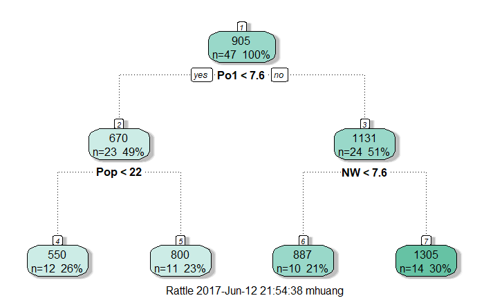

```r
library(rpart)
library(rattle)
library(RColorBrewer)
crimedf <- read.table('uscrime.txt',header=TRUE)
rpartAll <- rpart(Crime~.,data=crimedf)
fancyRpartPlot(rpartAll, palettes=c("BuGn"))
```

### running and viewing trees generated from tree library

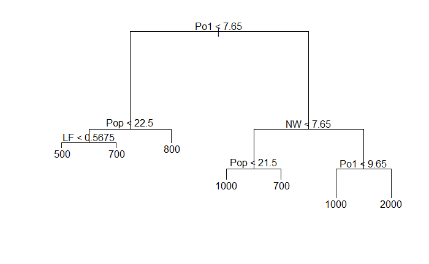

```r
library(tree)
treeAll <- tree(Crime~.,data=data.frame(crimedf))
plot(treeAll)
text(treeAll)
```

### Doing a quick R^2 check even though I feel like the tree model would do better because it looks more overfit.

```r
treeyhat <- predict(treeAll)
treeSSres <- sum((treeyhat-data$Crime)^2)
rpartyhat <- predict(rpartAll)
rpartSSres <- sum((rpartyhat-data$Crime)^2)
SStot <- sum((df$Crime - mean(df$Crime))^2)
treeR2=1-treeSSres/SStot
rpartR2=1-rpartSSres/SStot
print(paste0("tree library gave R^2 of ",treeR2))
```

[output not shown]

```r
print(paste0("rpart library gave R^2 of ",rpartR2))
```

[output not shown]

### Prune data back

Because we really have barely any data, we really shouldn’t have more than just 1 split. But we know that this would probably give a bad R^2 valued

```r
treePrune <- prune.tree(treeAll, best=2)
prunyhat <- predict(treePrune)
prunSSres <- sum((prunyhat - data$Crime)^2)
pruneR2=1-prunSSres/SStot
print(paste0("pruned tree gave R^2 of ",pruneR2))
```

[output not shown]

The ideal thing to do for this model is to actually run linear regression for each branch, then run cross validation on each of these model. This would give a better depiction of how well it works. However, I did run out of time for this project.

### Randomforest

Now we can run the randomForest model.

```r
library(randomForest)
numpred <- 5
forestData <- randomForest(Crime~., data=crimedf, mtry=numpred,importance=TRUE)
forestyhat <-predict(forestData)
ssres <-sum((forestyhat-data$Crime)^2)
SStot <- sum((df$Crime - mean(df$Crime))^2)
R2=1-SSres/SStot
print(paste0("R2 value: ",R2))
```

[output not shown]

### Cross Validation on Random Forest

```r
CVSSres <- 0
for (i in 1:nrow(crimedf))
{
  forestModel <- randomForest(Crime ~.,data=crimedf[-i,], mtry=numpred, importance = TRUE)
  CVSSres=CVSSres+(predict(forestModel, newdata=crimedf[i,]) - crimedf[i,16])^2
}
SStot <- sum((df$Crime - mean(df$Crime))^2)
R2=1-CVSSres/SStot
print(paste0("CV R2 value: ",R2))
```

```
[1] "CV R2 value: 0.439722888343764"
```

There’s also additional metrics that can help identify components that are helpful in separating the data. Below are two of them which identifies Po1 and Po2 as major impact factors.

```r
importance(forestData)
```

```
       %IncMSE IncNodePurity
M        3.298        206311
So       2.353         19315
Ed       1.202        214507
Po1     12.765       1306205
Po2     11.514       1082346
LF       3.481        306884
M.F      0.979        252441
Pop     -0.440        332450
NW       7.811        498001
U1       0.336        149666
U2       0.245        158145
Wealth   4.327        671945
Ineq    -1.026        252524
Prob     7.891        754485
Time     2.958        188670
```

[figure not shown]

# Question 3

Describe a situation or problem from your job, everyday life, current events, etc., for which a logistic regression model would be appropriate. List some (up to 5) predictors that you might use.

## Response

Logistic regression model would be useful in predicting the whether a patient will be admitted into the ED within the next year. Some of the factors that contribute to this include: * Whether they’ve been to the ED in the past year(risk of readmission) * Whether they have cardio vascular diseases * Whether they currently have a grouper of risky diagnoses * Whether they are currently on vasodilators * Whether they are overweight

# Question 4 Part 1

Using the [GermanCredit](http://archive.ics.uci.edu/ml/machine-learningdatabases/statlog/german/) data set ([description](http://archive.ics.uci.edu/ml/datasets/Statlog+%28German+Credit+Data%29)), use logistic regression to find a good predictive model for whether credit applicants are good credit risks or not. Show your model (factors used and their coefficients), the software output, and the quality of fit. You can use the glm function in R. To get a logistic regression (logit) model on data where the response is either zero or one, use family=binomial(link=“logit”) in your glm function call.

```r
credDF <- read.table("germancredit.txt", sep=" ")
#convert people who are good(1) to 0 and bad(2) to 1
credDF$V21[credDF$V21==1] <- 0
credDF$V21[credDF$V21==2] <- 1
credSub <- sample(1:nrow(credDF), size=round(0.6*(nrow(credDF))))
credTrain <- credDF[credSub,]
credVal <- credDF[-credSub,]
model=glm(V21~., family=binomial(link="logit"), data=credTrain)
y_hat <- predict(model, credVal, type="response")
y_pred <- as.integer(y_hat >0.5)
table(y_pred, credVal$V21)
```

```
y_pred   0   1
     0 248  58
     1  34  60
```

# Question 4 Part 2

Because the model gives a result between 0 and 1, it requires setting a threshold probability to separate between “good” and “bad” answers. In this data set, they estimate that incorrectly identifying a bad customer as good, is 5 times worse than incorrectly classifying a good customer as bad. Determine a good threshold probability based on your model.

```r
library(pROC)
roc(credVal$V21,y_pred)
```

```
Call:
roc.default(response = credVal$V21, predictor = y_pred)

Data: y_pred in 282 controls (credVal$V21 0) < 118 cases (credVal$V21 1).
Area under the curve: 0.694
```

```r
table <- as.matrix(table(y_pred,credVal$V21))
cost <- table[2,1] + 5*table[1,2]
```

```r
table <- as.matrix(table(y_pred,credVal$V21))
cost <- table[2,1] + 5*table[1,2]
print(table)
```

```
y_pred   0   1
     0 248  58
     1  34  60
```

```r
print(cost)
```

```
[1] 324
```